# Weather Exploration Project - Udacity

## Diego Merino Muñoz

First of all, I used the following SQL queries to extract the data:

- For my local City:

SELECT  
year,  
avg_temp as Average_Temperature  
FROM  
city_data  
WHERE  
city = 'Madrid'  
ORDER BY  
year

- For the Global Data:

SELECT  
year,  
avg_temp as average_temperature  
FROM  
global_data  
ORDER BY  
year

Now, we import the necessary libraries to take on our project:

```python
# Importing needed libraries for the exploration and Setting the matplotlib figure size
import pandas as pd
import numpy as np
import matplotlib.pyplot as plt
import csv

plt.rcParams["figure.figsize"] = (16,5)
```

Now it's time to load our data, selecting our index col and parsing the dates in case we need to manage them.

```python
# Loading the CSVs as Pandas dataframes, with the year as index and the dates parsed

city_data = pd.read_csv('citywide-results.csv', index_col='year', parse_dates=True)
global_data = pd.read_csv('global-data.csv', index_col = 'year', parse_dates= True)
```

We check for Null values that will cause trouble when calculating the moving average:

```python
# Checking for null Data on our dataframes
print('There are {} Null values in the City Dataframe'.format(city_data['average_temperature'].isnull().sum()))
print('There are {} Null values in the City Dataframe'.format(global_data['average_temperature'].isnull().sum()))
```

```
There are 4 Null values in the City Dataframe
There are 0 Null values in the City Dataframe
```

As there are just 4 Null Values on the cities Dataframe, we'll choose to drop them

```python
# Droping the NAs on the dataframe
city_data.dropna(axis=0, inplace = True)
```

Now, Let's create our moving Average values. I've chosen a decade because it seemed like a logical value to consider (a decade) for temperature changes.

```python
# Let's do a 10 year moving average
city_data = city_data['average_temperature'].to_frame()
global_data = global_data['average_temperature'].to_frame()

city_data['SMA10Year'] = city_data['average_temperature'].rolling(10).mean()
global_data['SMA10Year'] = global_data['average_temperature'].rolling(10).mean()
```

Now, let's compare the effect that our Moving Average had in our data

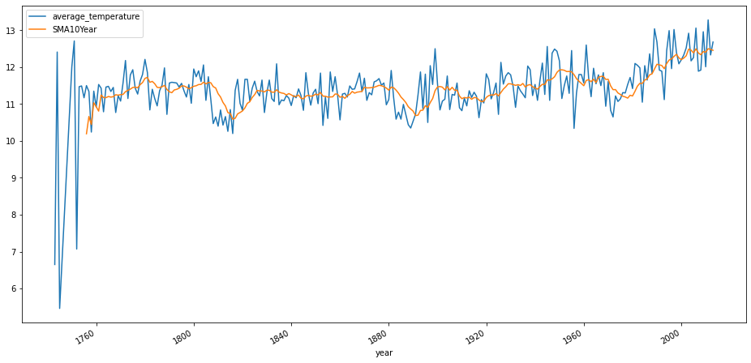

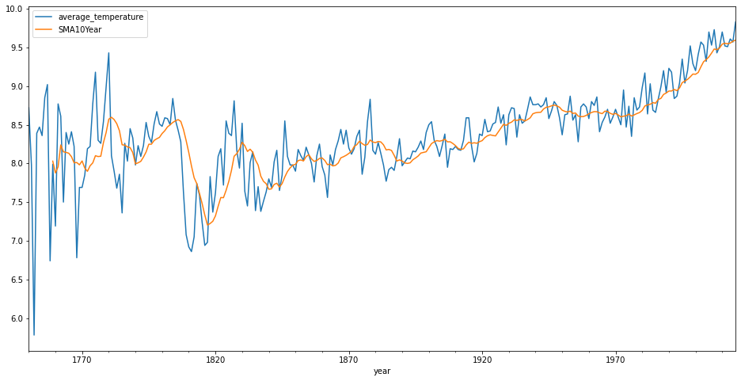

```python
# Comparing Moving Average to Granular data
city_data[['average_temperature', 'SMA10Year']].plot(label = 'Temperature', figsize = (16,8))
global_data[['average_temperature', 'SMA10Year']].plot(label = 'Temperature', figsize = (16,8))
```

Finally, let's plot our Moving Average data for Madrid and for the Global Temperature.

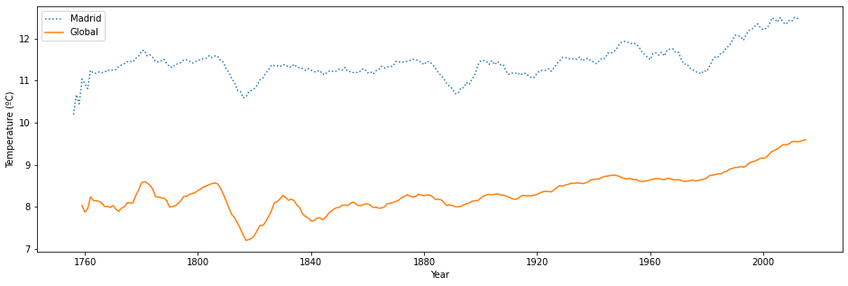

```python
plt.plot(city_data['SMA10Year'], label = 'Madrid', linestyle = ':')
plt.plot(global_data['SMA10Year'], label = 'Global', linestyle = '-')
plt.legend()
plt.xlabel('Year')
plt.ylabel('Temperature (ºC)')
plt.show()
```

## EXTRAS

Let's calculate the Correlation Coefficient between the two series

1. First of all, let's add the columns into a single dataframe:

```python
# Setup of the new dataframe
total_dataframe = city_data['SMA10Year'].to_frame()
total_dataframe.rename(columns={'SMA10Year':'Madrid'}, inplace= True)
total_dataframe['Global'] = global_data['SMA10Year']

# We drop the Na values created so that it's not a problem when we calculate the correlation coefficient

total_dataframe.dropna(inplace=True)

# Now We calculate the correlation coefficient

total_dataframe.corr(method= 'pearson')
```

|  | Madrid | Global |
| --- | --- | --- |
| Madrid | 1.000000 | 0.879192 |
| Global | 0.879192 | 1.000000 |

We observe that we have a really high correlation coefficient: 0.879

### Estimation of Madrid's temperature Based on the Global Temperature

#### Madrid's mean temperature:

```python
print('The Average temperature in Madrid is:  {}ºC'.format(total_dataframe['Madrid'].mean().round(2)))
```

```
The Average temperature in Madrid is:  11.44ºC
```

#### Global Mean Temperature:

```python
print('The Average Global temperature is:  {}ºC'.format(total_dataframe['Global'].mean().round(2)))
```

```
The Average Global temperature is:  8.34ºC
```